# Studying Smarter? Uncovering My Real Study Patterns

## About This Data

Over about 2 months, I logged every study session I completed on an external timer app— which recorded the date, how long I studied for and how many breaks I took. I also noted how many classes I attended that day, whether It felt productive, and where I studied manually. This data story will look into the totals/ averages for hours, breaks while looking into classes attended and locations possible effect on the these totals/averages.

I collected this data using a Google Form and stored it in a Google Sheet. Each row represents one study session.

## When Do I Actually Study?

The total hours i have studied on each day from march 23rd to May 11th seems to average out to about 20 hours for each day except thursday and saturday. This is interesting because i dont have any fixed schedule for studying and dont consciously choose to study less on thursday and saturday, so what else could be going on here?

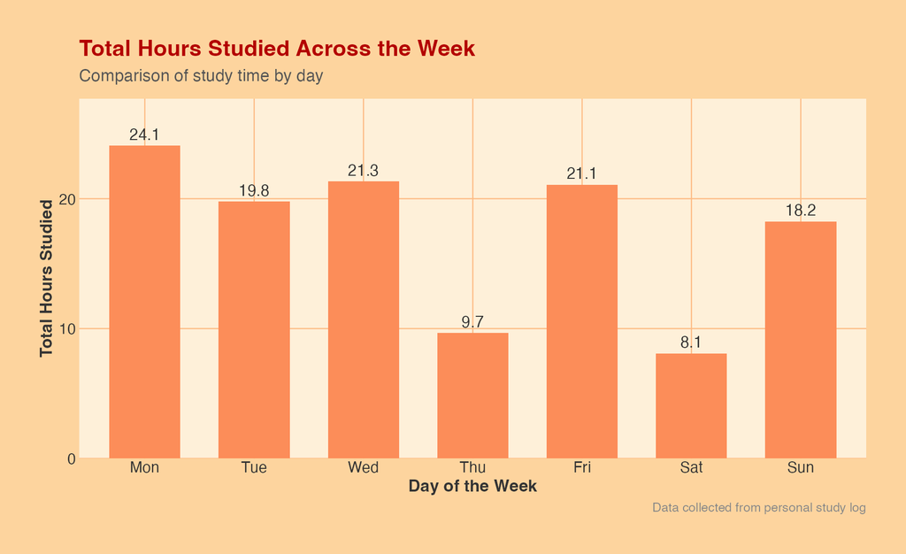

Going deeper into the total hours in search of an answer, i decided to find the average hours studied per day which still showed thursday and saturdays as my two lowest with the caveat that thursday was in a similar range to the other days. Indicating that the low total hours studied is due to frequency of studies on those days not length of study.

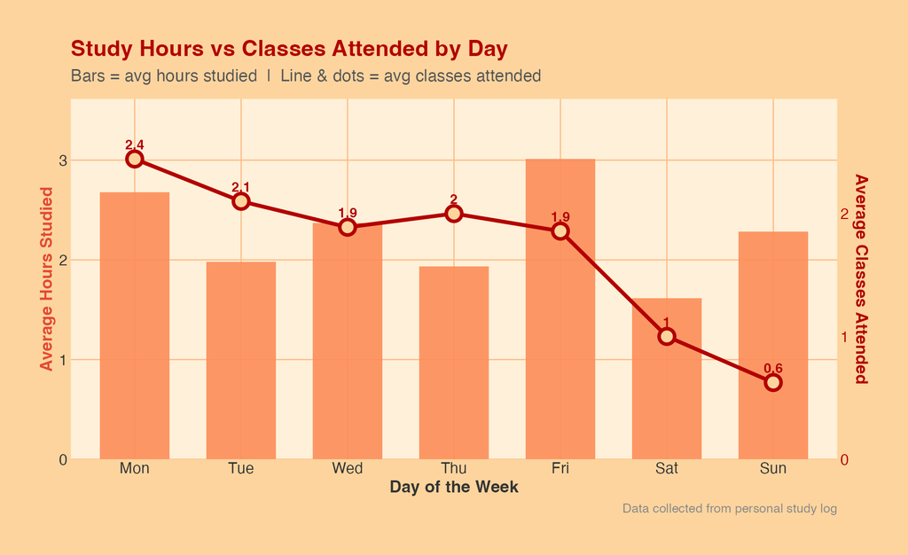

The pattern here suggests my studying is front- or mid-loaded in the week, with less happening toward the weekend. This might reflect lecture schedules or deadlines more than any deliberate planning.

## Do Classes Push Me to Study More?

One question I wanted to explore was whether attending more classes on a given day translated into more studying that day. You might expect it to — more class exposure could motivate revision — or the opposite, with a full day of classes leaving less time and energy for independent study.

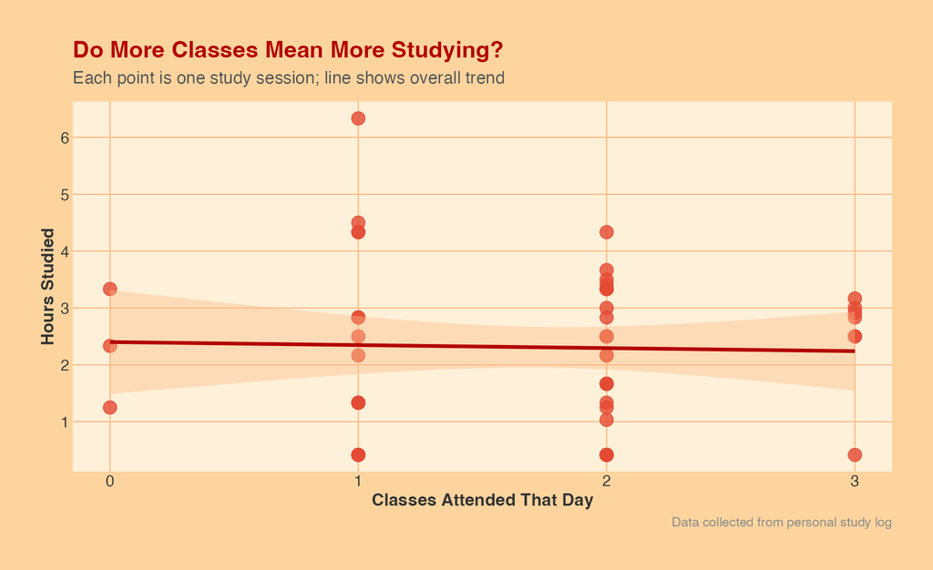

Scatter plot with a linear trend line showing the relationship between number of classes attended and hours studied that day

## Does Taking More Breaks Affect How Long I Study?

Break frequency is something I tracked carefully. I categorised sessions into low (3 or fewer breaks), medium (4 breaks), and high (5 or more breaks) and looked at whether break patterns related to overall study duration.

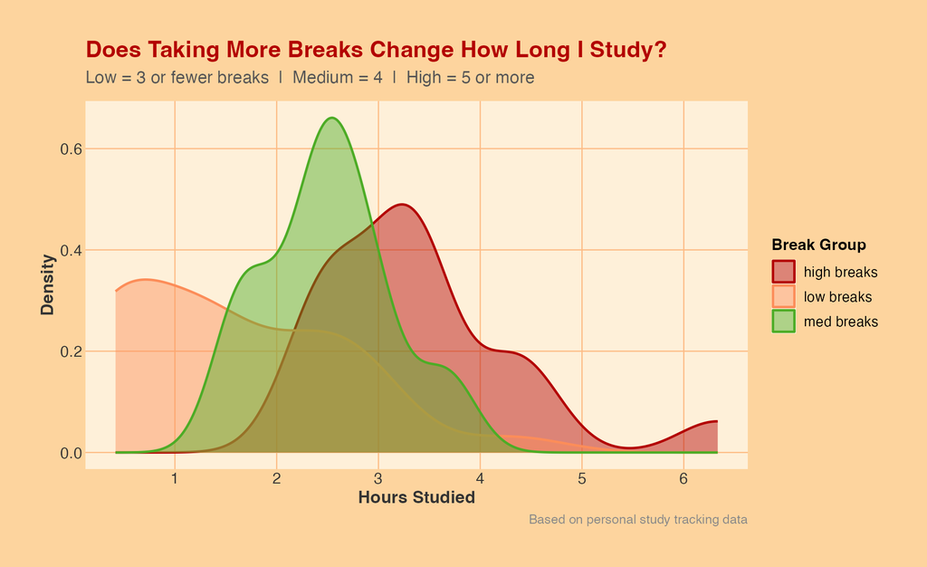

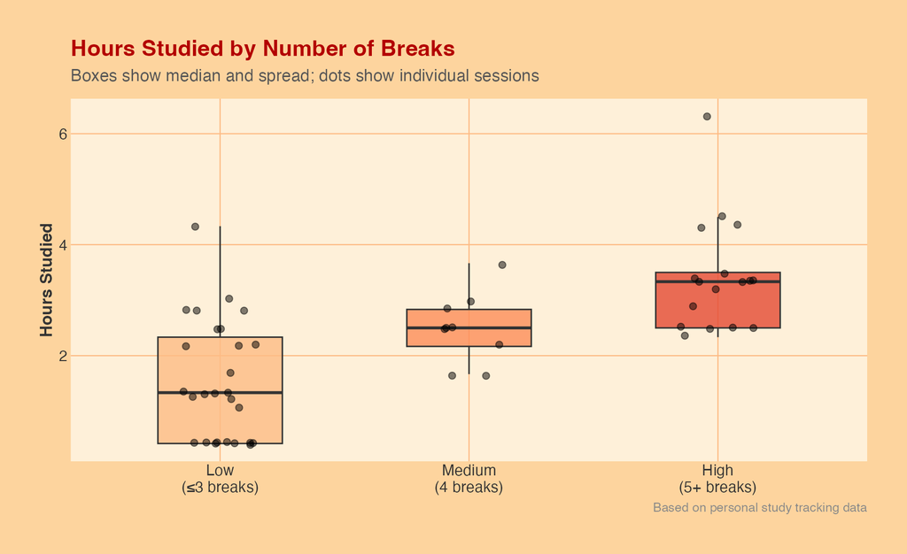

Box plots comparing hours studied across the three break groups, showing medians and spread for low, medium, and high break sessions

The density and box plots together tell an interesting story. Sessions with more breaks don’t necessarily end up being shorter — if anything, longer sessions naturally accumulate more breaks. This suggests breaks may be a feature of longer, more sustained study rather than a sign of distraction.

## Does Location Shape My Study Habits?

Finally, I looked at where I studied — at home versus away from home — and how that varied across the week.

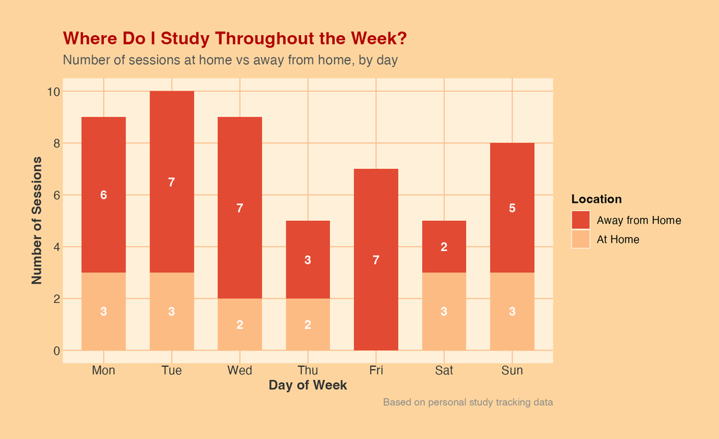

Stacked bar chart showing the number of study sessions at home versus away from home for each day of the week